# Data 621 Homework 1

Critical Thinking Group 3: Vyannna Hill, Jose Rodriguez, and Christian Uriostegui

2023-10-01

## Introduction of the MoneyBall game statistics from 1871 to 2006

For this analysis a Multiple Linear Regression Model (MLR) will be built. The objective is to predict how many games are won, in a given season, based on baseball game event metrics. The baseball game events include batting, strikeouts, fielding, and pitching. Each variable can have a positive or a negative influence on the number of wins for the season. For more details on variables, see section **1.1, About the Dataset**.

The final report will include the following sections:  
**1. Data Exploration:** high-level statistical information about the training data set. This includes, but is not limited to variable distributions, correlations, visualizations and completeness of the data.

**2. Data Preparation:** describes steps and techniques used to transform the data.

**3. Building models:** will report on several models, its accuracy, and steps taken to improve it.

**4. Model selection:** will outline the best model and why it was chosen among all the different alternatives.

## 1. Data Exploration

For building linear regression models, data exploration is usually the first step. Its a best practice which allows scientists to find discrepancies in the dataset before diving into model building. Moreover, the data quality can be quantified and visualized. The results are then used to formulate the model-building approach.

### 1.1 About the Dataset

The provided dataset contains two files in CSV format. One for training the MLR model, and one for generating predictions.

The following variables are found in the dataset:

| Variable Name | Definition | Theoretical Effect |
| --- | --- | --- |
| INDEX | Identification Variable (do not use) |  |
| TARGET_WINS | Number of wins | Response variable |
| TEAM_BATTING_H | Base hits by batters (1B,2B, 3B, HR) | Positive Impact on Wins |
| TEAM_BATTING_2B | Doubles by batters (2B) | Positive Impact on Wins |
| TEAM_BATTING_3B | Triples by batters (3B) | Positive Impact on Wins |
| TEAM_BATTING_HR | Homeruns by batters (4B) | Positive Impact on Wins |
| TEAM_BATTING_BB | Walks by batters | Positive Impact on Wins |
| TEAM_BATTING_HBP | Batters hit by pitch (get a free base) | Positive Impact on Wins |
| TEAM_BATTING_SO | Strikeouts by batters | Negative Impact on Wins |
| TEAM_BASERUN_SB | Stolen bases | Positive Impact on Wins |
| TEAM_BASERUN_CS | Caught stealing | Negative Impact on Wins |
| TEAM_FIELDING_E | Errors | Negative Impact on Wins |
| TEAM_FIELDING_DP | Double Plays | Positive Impact on Wins |
| TEAM_PITCHING_BB | Walks allowed | Negative Impact on Wins |
| TEAM_PITCHING_H | Hits allowed | Negative Impact on Wins |
| TEAM_PITCHING_HR | Homeruns allowed | Negative Impact on Wins |
| TEAM_PITCHING_SO | Strikeouts by pitchers | Positive Impact on Wins |

### 1.2 Descriptive Statistical Analysis

On average, teams saw 80 wins in a given season. The most prolific season saw a high of 146, whereas the least saw a value of 0. One path of preemptive checks on normality is to view the binomial distribution of the response variable. The distribution for TARGET_WINS, the response variable for this analysis, appears to be normally distributed. It can be inferred that it is a good candidate for a linear regression model. It should be noted there is a slight dip in density distribution around 70 wins. This could reveal an issue with the unprocessed data set.

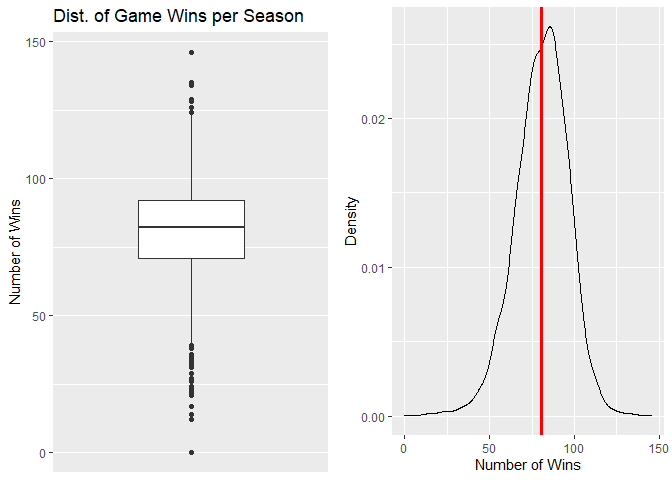

### 1.3 Data Wrangling Pre-inspection:

```r
summary(training_set)
```

```
##      INDEX         TARGET_WINS     TEAM_BATTING_H TEAM_BATTING_2B
##  Min.   :   1.0   Min.   :  0.00   Min.   : 891   Min.   : 69.0
##  1st Qu.: 630.8   1st Qu.: 71.00   1st Qu.:1383   1st Qu.:208.0
##  Median :1270.5   Median : 82.00   Median :1454   Median :238.0
##  Mean   :1268.5   Mean   : 80.79   Mean   :1469   Mean   :241.2
##  3rd Qu.:1915.5   3rd Qu.: 92.00   3rd Qu.:1537   3rd Qu.:273.0
##  Max.   :2535.0   Max.   :146.00   Max.   :2554   Max.   :458.0
##
##  TEAM_BATTING_3B  TEAM_BATTING_HR  TEAM_BATTING_BB TEAM_BATTING_SO
##  Min.   :  0.00   Min.   :  0.00   Min.   :  0.0   Min.   :   0.0
##  1st Qu.: 34.00   1st Qu.: 42.00   1st Qu.:451.0   1st Qu.: 548.0
##  Median : 47.00   Median :102.00   Median :512.0   Median : 750.0
##  Mean   : 55.25   Mean   : 99.61   Mean   :501.6   Mean   : 735.6
##  3rd Qu.: 72.00   3rd Qu.:147.00   3rd Qu.:580.0   3rd Qu.: 930.0
##  Max.   :223.00   Max.   :264.00   Max.   :878.0   Max.   :1399.0
##                                                    NA's   :102
##  TEAM_BASERUN_SB TEAM_BASERUN_CS TEAM_BATTING_HBP TEAM_PITCHING_H
##  Min.   :  0.0   Min.   :  0.0   Min.   :29.00    Min.   : 1137
##  1st Qu.: 66.0   1st Qu.: 38.0   1st Qu.:50.50    1st Qu.: 1419
##  Median :101.0   Median : 49.0   Median :58.00    Median : 1518
##  Mean   :124.8   Mean   : 52.8   Mean   :59.36    Mean   : 1779
##  3rd Qu.:156.0   3rd Qu.: 62.0   3rd Qu.:67.00    3rd Qu.: 1682
##  Max.   :697.0   Max.   :201.0   Max.   :95.00    Max.   :30132
##  NA's   :131     NA's   :772     NA's   :2085
##  TEAM_PITCHING_HR TEAM_PITCHING_BB TEAM_PITCHING_SO  TEAM_FIELDING_E
##  Min.   :  0.0    Min.   :   0.0   Min.   :    0.0   Min.   :  65.0
##  1st Qu.: 50.0    1st Qu.: 476.0   1st Qu.:  615.0   1st Qu.: 127.0
##  Median :107.0    Median : 536.5   Median :  813.5   Median : 159.0
##  Mean   :105.7    Mean   : 553.0   Mean   :  817.7   Mean   : 246.5
##  3rd Qu.:150.0    3rd Qu.: 611.0   3rd Qu.:  968.0   3rd Qu.: 249.2
##  Max.   :343.0    Max.   :3645.0   Max.   :19278.0   Max.   :1898.0
##                                    NA's   :102
##  TEAM_FIELDING_DP
##  Min.   : 52.0
##  1st Qu.:131.0
##  Median :149.0
##  Mean   :146.4
##  3rd Qu.:164.0
##  Max.   :228.0
##  NA's   :286
```

#### 1.3.1 Inspecting for null values:

While examining the dataset it was found that several variables have a large count of NA values. The largest unaccounted amount of values fall with batters hit by the pitchers. We do not have insight from the survey team to deduce if these NAs reflect no values recorded or a human imputation error. This will have to be sorted for the analysis.

1. Are there missing values in the dataset?

```
## [1] TRUE
```

2. How many? What is the proportion of missing values?

```
## [1] 3478
```

```
## [1] 0.08988938
```

3. Which variables are affected? Which contain the most missing values?

```
##            INDEX      TARGET_WINS   TEAM_BATTING_H  TEAM_BATTING_2B
##                0                0                0                0
##  TEAM_BATTING_3B  TEAM_BATTING_HR  TEAM_BATTING_BB  TEAM_BATTING_SO
##                0                0                0              102
##  TEAM_BASERUN_SB  TEAM_BASERUN_CS TEAM_BATTING_HBP  TEAM_PITCHING_H
##              131              772             2085                0
## TEAM_PITCHING_HR TEAM_PITCHING_BB TEAM_PITCHING_SO  TEAM_FIELDING_E
##                0                0              102                0
## TEAM_FIELDING_DP
##              286
```

### 1.4 Investigating Relationships

Two possible predictor values were selected to plot against TARGET_WINS. TEAM_BATTING_BB (Walks by Batter), and TEAM_BATTING_HR (Home runs by Batter). There is concern for both variables as they do not appear to have a linear relationship with TARGET_WINS. Ultimately, this can be influenced by another variables.??

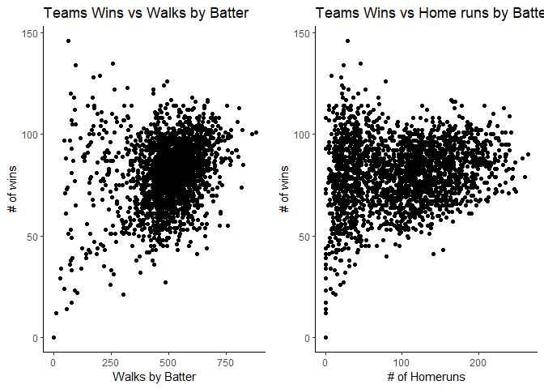

When visualizing correlation strength between target wins and the other predictor variables, we can see that there aren’t many significant relationships. The batting variables all have positive correlations with Target Wins. Some of the pitching and fielding variables have negative correlations. A trend we’re seeing is that the offense variables, which include batting, lead to more wins while some of the defensive stats can negatively affect wins. When creating our models, it may be worth creating them with this in mind. Some of the standout pairings are listed below.

1. Target Wins & Team Batting Hits TARGET_WINS & TEAM_BATTING_H have a moderately positive correlation of 0.39 which suggests that teams with more batting hits have more wins
2. Target Wins & Team Batting Doubles TARGET_WINS & TEAM_BATTING_2B have a weak positive relationship with a correlation of 0.29. Teams with more batting doubles will have slightly more wins
3. Target Wins & Team Batting Walks TARGET_WINS & TEAM_BATTING_BB have a weak positive correlation of 0.23. Teams with more batting walks have slightly more wins
4. Target Wins & Team Errors TARGET_WINS & TEAM_FIELDING_E have a weak negative correlation of 0.18. Teams with more fielding errors will have slightly less wins.
5. Target Wins & Team Pitching H TARGET WINS & TEAM_PITCHING_H has a weak negative correlation of -0.11. Teams with more hits allowed will have slightly less wins.

[figure not shown]

## 2. Data Preparation

From the previous section, there is no indication that NAs reflect zeros in the dataset. As such, they will be assumed to be missing values. Missing values can be handled with two common techniques.

The first technique consists of completely removing all data points containing any amount of NAs. In other words, this method filters to rows that are complete. This method includes all the original predictors at the risk of removing more than 90% of the dataset. A reduction from 2276 to 191 data points. This technique is not ideal as the reduced number of observations can negatively influence the model’s regression.

The alternative path consists of utilizing imputation to assign synthetic values. Imputation can take many different forms, but they all accomplish the same goal: to assume a value based on the distribution of the data. For this particular analysis, MICE is used to predict the missing values in the dataset. It involves removing predictors that pass a given threshold of randomness.

During the data exploration stage, it was found that variables “TEAM_BASERUN_CS” and “TEAM_BATTING_HBP” have the highest count of missing values. This is a strong indication that its NAs are not missing at random. It is best to remove these predictors before running the MICE model on the data set. After its removal, a model can be trained.

### 2.1 Using MICE Imputation

[figure not shown]

```r
#Technique #2: Drop predictors HBP and CS and use MICE imputation
train.c1<-training_set %>%
  select(-c(INDEX,TEAM_BATTING_HBP,TEAM_BASERUN_CS)) #Filter dataset

train.mice<-complete(mice(train.c1,method = "lasso.norm",seed = 333)) #Using MICE

summary(train.mice)
```

[output not shown]

### 2.2 Calculating New Predictors

*New Baseball Variables +STW Ratio: The times a pitcher strikeouts over the times a batter walks to first base +Total Bases: Number of bases gain by batter by hits

### 2.3 Scaling the Data

Scaling the training set before analysis as the new variables are not on the same scale. Now, the training set is ready to be fitted!

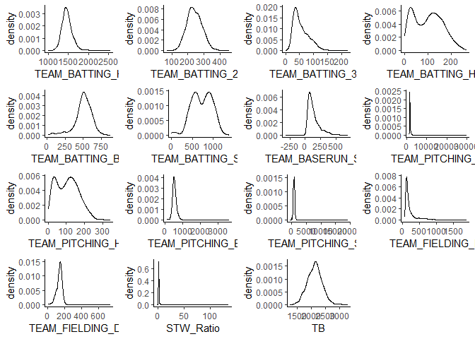

## 3. Building Models

Now its time to create three linear models with distinct predictor variable subsets and compare the results.

### 3.1 Model Fit 1: Full Model

The first model will be a full model, meaning it will include all predictors against *TARGET_WINS*.

Looking at the coefficient numbers, we notice something odd. Batting variables that should theoretically have a positive effect on winning like *TEAM_BATTING_H*, *TEAM_BATTING_2B*, *TEAM_BATTING_3B*, and *TEAM_BATTING_HR* have a negative coefficient. This means for every increase in this stat, it decreases the number of wins. We see the inverse for some variables. *TEAM_PITCHING_H* or hits allowed, a stat which has a negative impact on wins, has a positive coefficient. We suspect this is due to the effect of having all the predictor values together.

This model has the most predictive values, contains 12 statistically significant variables, and has an R squared value of 0.3816.

```
##
## Call:
## lm(formula = TARGET_WINS ~ ., data = train_set)
##
## Residuals:
##     Min      1Q  Median      3Q     Max
## -3.2718 -0.5006 -0.0076  0.5104  3.6955
##
## Coefficients:
##                    Estimate Std. Error t value Pr(>|t|)
## (Intercept)       2.250e-15  1.649e-02   0.000 1.000000
## TEAM_BATTING_H   -4.630e-01  1.752e-01  -2.643 0.008273 **
## TEAM_BATTING_2B  -3.663e-01  6.152e-02  -5.954 3.02e-09 ***
## TEAM_BATTING_3B  -1.181e-01  7.467e-02  -1.582 0.113778
## TEAM_BATTING_HR  -8.627e-01  2.289e-01  -3.768 0.000169 ***
## TEAM_BATTING_BB   2.770e-01  5.585e-02   4.960 7.56e-07 ***
## TEAM_BATTING_SO  -3.581e-01  4.185e-02  -8.557  < 2e-16 ***
## TEAM_BASERUN_SB   3.175e-01  2.871e-02  11.057  < 2e-16 ***
## TEAM_PITCHING_H   1.520e-01  4.917e-02   3.092 0.002010 **
## TEAM_PITCHING_HR  9.923e-04  9.470e-02   0.010 0.991640
## TEAM_PITCHING_BB -1.660e-01  4.834e-02  -3.435 0.000604 ***
## TEAM_PITCHING_SO  2.819e-01  6.332e-02   4.453 8.89e-06 ***
## TEAM_FIELDING_E  -8.449e-01  4.654e-02 -18.156  < 2e-16 ***
## TEAM_FIELDING_DP -2.941e-01  2.660e-02 -11.056  < 2e-16 ***
## STW_Ratio        -8.871e-02  5.601e-02  -1.584 0.113403
## TB                1.475e+00  3.139e-01   4.701 2.75e-06 ***
## ---
## Signif. codes:  0 '***' 0.001 '**' 0.01 '*' 0.05 '.' 0.1 ' ' 1
##
## Residual standard error: 0.7864 on 2259 degrees of freedom
## Multiple R-squared:  0.3857, Adjusted R-squared:  0.3816
## F-statistic: 94.57 on 15 and 2259 DF,  p-value: < 2.2e-16
```

When investigating the residual plots, linearity and homoscedasticity is observed (variance is constant). In the Normal Q-Q plot it can be seen that most points adhere to the diagonal line indicating a normal distribution of residuals. In the leverage visual, we can notice a few deviated points in the model.

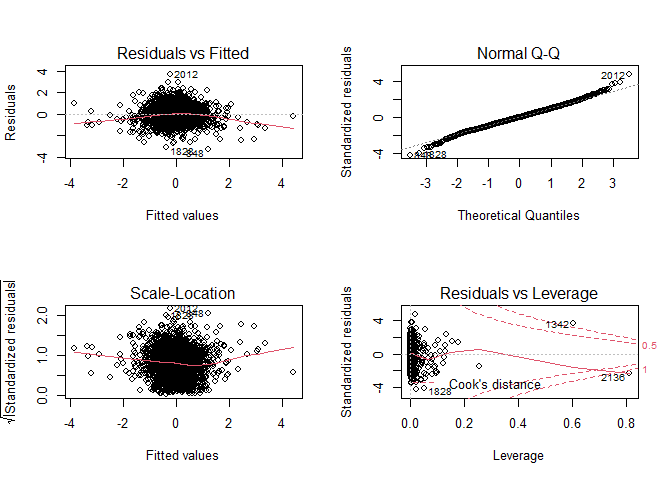

### 3.2 Model Fit 2: Modeling Batting Variables

The second model will only contain batting variables such as *TEAM_BATTING_H* and *TEAM_BATTING_2B* (offense variables). Batting variables involve scoring points for a team, therefore increasing the chances of a team winning. Theoretically, these should be strong predictors.

This model contains less predictor variables when compared to model 1, however it is comprised mainly of statistically significant variables. A lower R squared value is observed, meaning that fielding and pitching explains a large portion of variance.

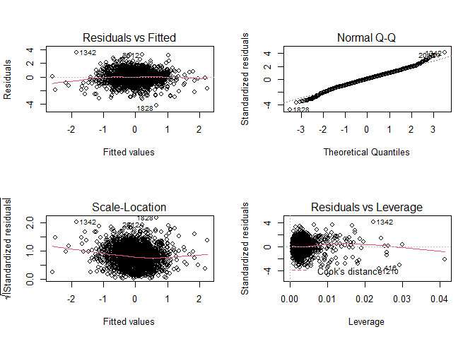

### 3.3 Model Fit 3: Modeling Pitching and Fielding Variables

The third model will only contain pitching and fielding stats (defensive variables). Outside of batting offense, pitching is important because it can limit the scoring of the opposing team. Similarly, the less Fielding Errors - which can give up scoring opportunities - the higher chances of winning. Fielding Double Plays - which is the ability to achieve two outs in a defensive play - can also increase the chances of a win. This model can also potentially give us a high winning percentage.

```r
#third model with pitching and fielding variables
fit3 <- lm(TARGET_WINS ~ TEAM_PITCHING_H + TEAM_PITCHING_HR + TEAM_PITCHING_BB + TEAM_PITCHING_SO + TEAM_FIELDING_E + TEAM_FIELDING_DP, data = train_set)
summary(fit3)
```

```
##
## Call:
## lm(formula = TARGET_WINS ~ TEAM_PITCHING_H + TEAM_PITCHING_HR +
##     TEAM_PITCHING_BB + TEAM_PITCHING_SO + TEAM_FIELDING_E + TEAM_FIELDING_DP,
##     data = train_set)
##
## Residuals:
##     Min      1Q  Median      3Q     Max
## -4.5424 -0.5741  0.0033  0.5928  4.1816
##
## Coefficients:
##                    Estimate Std. Error t value Pr(>|t|)
## (Intercept)       1.024e-15  1.921e-02   0.000    1.000
## TEAM_PITCHING_H   3.521e-01  3.189e-02  11.042   <2e-16 ***
## TEAM_PITCHING_HR  3.071e-02  2.917e-02   1.053    0.293
## TEAM_PITCHING_BB  1.881e-01  2.118e-02   8.883   <2e-16 ***
## TEAM_PITCHING_SO -1.822e-01  2.079e-02  -8.763   <2e-16 ***
## TEAM_FIELDING_E  -5.733e-01  4.598e-02 -12.467   <2e-16 ***
## TEAM_FIELDING_DP -3.896e-01  2.664e-02 -14.626   <2e-16 ***
## ---
## Signif. codes:  0 '***' 0.001 '**' 0.01 '*' 0.05 '.' 0.1 ' ' 1
##
## Residual standard error: 0.9162 on 2268 degrees of freedom
## Multiple R-squared:  0.1628, Adjusted R-squared:  0.1606
## F-statistic: 73.51 on 6 and 2268 DF,  p-value: < 2.2e-16
```

This model does not appear linear based on the vertical shape of the data points, it is homoscedastic. Though the model is normally distributed, compared to the previous models, it has the most points that fall off the line on both ends of the tail. This model appears to be the weakest model of the three.

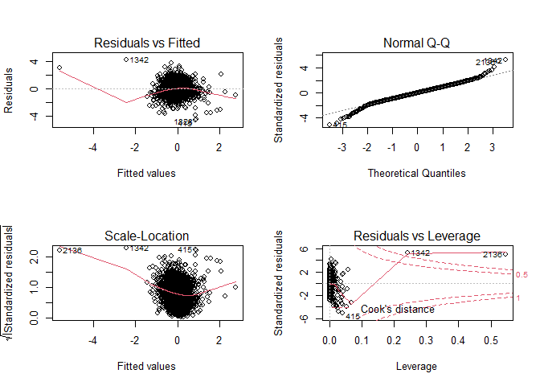

```r
par(mfrow=c(2, 2))
plot(fit3)
```

This model is comprised mostly of statistically variables, but has the lowest R squared compared to the other models.

## 4. Model Selection

Next, residuals were inspected to check model conformance. For model 1 and 2 there residuals seem to be normally distributed and display constant variance. However, model 3 display made it very poor candidate in terms of residual diagnostics and Adjusted R squared score.

Furthermore, it would be a good idea to explore removing TEAM_BATTING_HR as it has a high correlation to TEAM_BATTING_SO and TEAM_PITCHING_HR.

Predictions on test_set:

[output not shown]

[output cut: 11 more lines]

[output not shown]

## Appendix

```r
library(tidyverse)
library(ggpubr)
library(corrplot)
library(mice)
library(NHANES)
library(naniar)
library(GGally)
library(faraway)

training_set<-read_csv("https://raw.githubusercontent.com/Vy4thewin/criticalthinking3/main/moneyball-training-data.csv")
test_set<-read_csv("https://raw.githubusercontent.com/Vy4thewin/criticalthinking3/main/moneyball-evaluation-data.csv")
require(gridExtra)
plot1 <- ggplot() + # Boxplot of TARGET_WINS
  geom_boxplot(aes(y = training_set$TARGET_WINS)) +
  scale_x_discrete( ) +
  labs(title = "Dist. of Game Wins per Season",
       y = "Number of Wins")

# compute mean TARTGET_WINS
mean_tw <- training_set %>%
  pull(TARGET_WINS) %>%
  mean() %>%
  signif(6)

plot2 <- ggplot( #review distribution of the response variable, see if not bi-modal
  data=training_set, aes(x=TARGET_WINS))+
  geom_density()+
  labs(y = "Density",
       x = "Number of Wins")+
  geom_vline(xintercept=mean_tw, size=1.2, color="red")


grid.arrange(plot1, plot2, ncol=2)
summary(training_set)
any_na(training_set)
n_miss(training_set)
prop_miss(training_set)
training_set %>% is.na() %>% colSums()
#See the number of NAs per columns. Noticed Batters hit per pitch has the highest count
colSums(is.na(training_set))

#Visually checking for a positive linear trend with a singular predictor value
g<-ggplot(training_set,aes(x=TEAM_BATTING_BB,y=TARGET_WINS))+geom_point()+labs(title = "Teams Wins vs Walks by Batter",x="Walks by Batter",y="# of wins")+theme_classic()

# plotting the wins vs home runs
g1<-ggplot(training_set,aes(x=TEAM_BATTING_HR,y=TARGET_WINS))+geom_point()+labs(title = "Teams Wins vs Home runs by Batter",x="# of Homeruns",y="# of wins")+theme_classic()

#Viewing multiple graphs with a selected predictor variable and its response (wins)
ggarrange(g,g1,ncol = 2,nrow = 1)

ggpairs(training_set)
#Technique #1: removing rows with any NAs
#Noticed there are entries with NAs values that cannot be replaced with a formula. These entries will be removed from the training_set to prevent a inaccurate model
training_set_na_rem <- na.omit(training_set)

#remove the index column as it does not a have effect on the data
train.c2<-training_set_na_rem %>%
  select(-c(INDEX))

summary(train.c2)
#Technique #2: Drop predictors HBP and CS and use MICE imputation
train.c1<-training_set %>%
  select(-c(INDEX,TEAM_BATTING_HBP,TEAM_BASERUN_CS)) #Filter dataset

train.mice<-complete(mice(train.c1,method = "lasso.norm",seed = 333)) #Using MICE

summary(train.mice)
#Seeing the correlation between non-NA predictors to indicate mutli-collinearity
corrplot(cor(train.mice[,2:14]),method = "number",type="lower", tl.srt = .71,number.cex=0.75)
# Found some baseball formulas here to add onto our analysis
#STW= pitchers strikeouts/ walks by batter
train.mice<-train.mice %>% mutate(STW_Ratio=TEAM_PITCHING_SO/TEAM_BATTING_BB)

#total bases=[H + 2B + (2 X 3B) + (3 X HR)].
train.mice<-train.mice%>%mutate(TB=TEAM_BATTING_H+TEAM_BATTING_2B+(2*TEAM_BATTING_3B)+(3*TEAM_BATTING_HR))

#two observations had NAs
train.mice<-na.omit(train.mice)

#review new columns
head(train.mice,3)
#see any possible predictors for skeweness and apply transformations before fitting
g1<-ggplot(data=train.mice,aes(x=TEAM_BATTING_H))+geom_density()+theme_classic()
g2<-ggplot(data=train.mice,aes(x=TEAM_BATTING_2B))+geom_density()+theme_classic()
g3<-ggplot(data=train.mice,aes(x=TEAM_BATTING_3B))+geom_density()+theme_classic()
g4<-ggplot(data=train.mice,aes(x=TEAM_BATTING_HR))+geom_density()+theme_classic()
g5<-ggplot(data=train.mice,aes(x=TEAM_BATTING_BB))+geom_density()+theme_classic()
g6<-ggplot(data=train.mice,aes(x=TEAM_BATTING_SO))+geom_density()+theme_classic()
g7<-ggplot(data=train.mice,aes(x=TEAM_BASERUN_SB))+geom_density()+theme_classic()
g8<-ggplot(data=train.mice,aes(x=TEAM_PITCHING_H))+geom_density()+theme_classic()
g9<-ggplot(data=train.mice,aes(x=TEAM_PITCHING_HR))+geom_density()+theme_classic()
g10<-ggplot(data=train.mice,aes(x=TEAM_PITCHING_BB))+geom_density()+theme_classic()
g11<-ggplot(data=train.mice,aes(x=TEAM_PITCHING_SO))+geom_density()+theme_classic()
g12<-ggplot(data=train.mice,aes(x=TEAM_FIELDING_E))+geom_density()+theme_classic()
g13<-ggplot(data=train.mice,aes(x=TEAM_FIELDING_DP))+geom_density()+theme_classic()
g14<-ggplot(data=train.mice,aes(x=STW_Ratio))+geom_density()+theme_classic()
g16<-ggplot(data=train.mice,aes(x=TB))+geom_density()+theme_classic()
ggarrange(g1,g2,g3,g4,g5,g6,g7,g8,g9,g10,g11,g12,g13,g14,g16,ncol = 4,nrow = 4)

#only 2b appears to be normal, let's fixed the variables that are positively skewed with a log10
#columns 15,12,8 cannot be transformed as some instances have negative numbers
train.mice<-train.mice%>%mutate_at(c(2,9,11,13,14),~log10(.))


#scale the training set so its easier for the system to process the data in the regression model
train_set<-data.frame(scale(train.mice))
#first model using all predictors
fit1 = lm(TARGET_WINS ~., data = train_set)
summary(fit1)
par(mfrow=c(2, 2))
plot(fit1)
plot(fitted(fit1),residuals(fit1),xlab="Fitted",ylab="Residuals")
abline(h=0)
#Removing the largest outlier point we have a very similar R squared.
cook <- cooks.distance(fit1)
halfnorm(cook,2, ylab="Cook’s distances")
#first model using all predictors
fit1i = lm(TARGET_WINS ~., data = train_set, subset=(cook < max(cook)))
summary(fit1i)
#second model with just batting variables
fit2 <- lm(TARGET_WINS ~ TEAM_BATTING_H + TEAM_BATTING_2B + TEAM_BATTING_3B + TEAM_BATTING_HR + TEAM_BATTING_BB + TEAM_BATTING_SO, data = train_set)
summary(fit2)
par(mfrow=c(2, 2))
plot(fit2)
#third model with pitching and fielding variables
fit3 <- lm(TARGET_WINS ~ TEAM_PITCHING_H + TEAM_PITCHING_HR + TEAM_PITCHING_BB + TEAM_PITCHING_SO + TEAM_FIELDING_E + TEAM_FIELDING_DP, data = train_set)
summary(fit3)
par(mfrow=c(2, 2))
plot(fit3)
#data cleanup
test.c1 <-test_set %>%
  select(-c(INDEX,TEAM_BATTING_HBP,TEAM_BASERUN_CS)) #Filter dataset

test.mice<-complete(mice(test.c1,method = "lasso.norm",seed = 333)) #Using MICE

test.mice<-test.mice %>%
  mutate(STW_Ratio=TEAM_PITCHING_SO/TEAM_BATTING_BB)

#total bases=[H + 2B + (2 X 3B) + (3 X HR)].
test.mice<-test.mice%>%
  mutate(TB=TEAM_BATTING_H+TEAM_BATTING_2B+(2*TEAM_BATTING_3B)+(3*TEAM_BATTING_HR))

#X observations had NAs
test.mice<-na.omit(test.mice)

test.mice<-test.mice%>%
  mutate_at(c(1,8,10,12,13),~log10(.))

test_set<-data.frame(scale(test.mice))

#predict
s.pred <- predict(fit1,new=test_set)

# backtransform scale:
(pred <- s.pred * sd(train.mice$TARGET_WINS) + mean(train.mice$TARGET_WINS))
```

[^1]: https://www.mlb.com/glossary/advanced-stats
[^2]: http://hosted.stats.com/mlb/stats.asp?file=glossary